# Investigation of bike hiring trips

## Investigation Overview

In this investigation, I wanted to investigate trip characteristics and take a look at the features of user, trip and time factor

## Dataset Overview

The dataset consists of (183412, 20) columns and rows respectively.  
It describes bike trips in Feb 2019 with some data about users including their birth year, user type and gender and some features abou the trip icluding duration and stations.

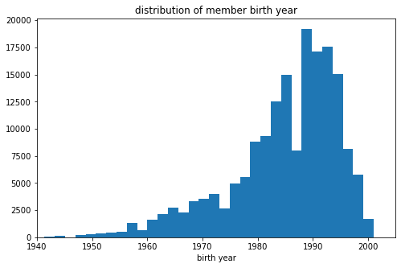

## Distribution of Duration

Trips vary in duration. Here it is displayed in minutes

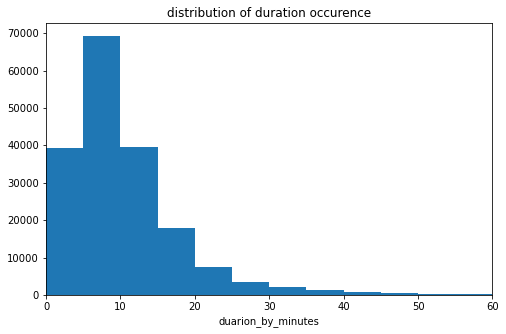

## When are users tend to hire bike along the day?

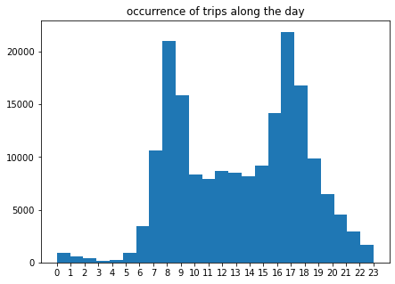

## duration vs start hour

How does trip duraion vary allover the day?

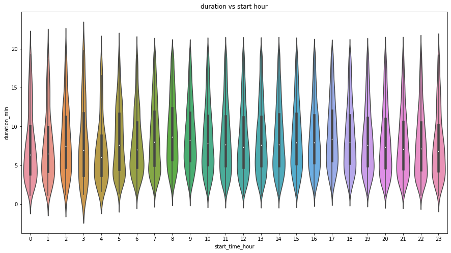

## Customer VS. Subscriber duration along the week

We can notice that customers have longer trips all over the week with interesting rise on Mondays with both customers and subscribers have longer trips at weekends

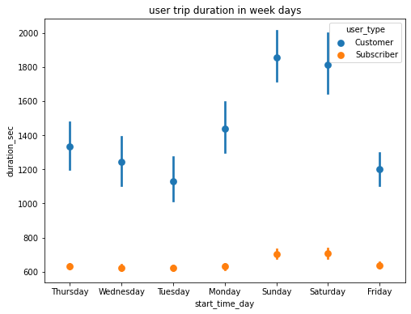

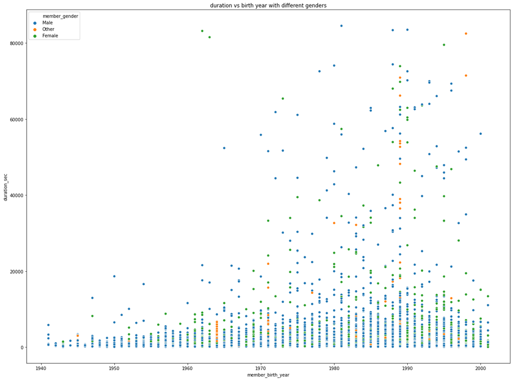